# Sheriffs Agencies and 287(g) arrests analysis

Andrew Ba Tran

To see R analysis code and comments, click **Code > Show All Code** at the top right.

```r
# Load data from FBI UCR

# employees data
employees <- read_csv("../../data/raw_data/ucr_agencies_employees_2019.csv")
employees_last <- employees %>%
  group_by(ori) %>%
  arrange(desc(year)) %>%
  ungroup()

# arrests data
arrests <- read_csv("../../data/raw_data/ucr_agencies_arrests_2019.csv")

# load crosswalk data from Inter-university Consortium for Political and Social Research

# To proceed, download the crosswalk zip folder from the link below
# https://www.icpsr.umich.edu/web/NACJD/studies/35158
# And unzip the folder into the `data/raw_data` folder
# then you can run this successfully

load("../../data/raw_data/ICPSR_35158/DS0001/35158-0001-Data.rda")

# save it as crosswalk dataframe
crosswalk <- da35158.0001

# remove the preloaded data
rm(da35158.0001)
```

```r
emp <- employees %>%
  # filter on later than 2004
  filter(year>=2005)

# joining number of employees to arrests data
joined <- emp %>%
  left_join(arrests)

joined <- joined %>%
  left_join(crosswalk, by=c("ori"="ORI9")) %>%
  # filtering out rows that reported no arrests
  filter(!is.na(all_other_offenses)) %>%
  # filters out 4,990 agencies that did not submit employee count info
  filter(!is.na(officers_total)) %>%
  # filtering out weird outlier
  filter(ori!="IN0080100" | year!=2013)
  # a more comprehensive filtering of outliers occurs later in the process

# replacing NAs with zeroes in the crime data
joined$all_other_offenses <- ifelse(is.na(joined$all_other_offenses),  0, joined$all_other_offenses)
joined$drug_grand_total <- ifelse(is.na(joined$drug_grand_total), 0, joined$drug_grand_total)
joined$simple_assault <- ifelse(is.na(joined$simple_assault), 0, joined$simple_assault)
joined$arson <- ifelse(is.na(joined$arson), 0, joined$arson)

joined$dui <- ifelse(is.na(joined$dui), 0, joined$dui)
joined$larceny <- ifelse(is.na(joined$larceny), 0, joined$larceny)
joined$aggravated_assault <- ifelse(is.na(joined$aggravated_assault), 0, joined$aggravated_assault)
joined$drunkness <- ifelse(is.na(joined$drunkness), 0, joined$drunkness)
joined$burglary <- ifelse(is.na(joined$burglary), 0, joined$burglary)

joined$curfew <- ifelse(is.na(joined$curfew),  0, joined$curfew)
joined$disorderly_conduct <- ifelse(is.na(joined$disorderly_conduct),  0, joined$disorderly_conduct)
joined$embezzlement <- ifelse(is.na(joined$embezzlement),  0, joined$embezzlement)
joined$forgery <- ifelse(is.na(joined$forgery),  0, joined$forgery)
joined$fraud <- ifelse(is.na(joined$fraud),  0, joined$fraud)
joined$gambling_total <- ifelse(is.na(joined$gambling_total),  0, joined$gambling_total)
joined$human_trafficking_commercial_sex_traffic <- ifelse(is.na(joined$human_trafficking_commercial_sex_traffic),  0, joined$human_trafficking_commercial_sex_traffic)
joined$human_trafficking_servitude <- ifelse(is.na(joined$human_trafficking_servitude),  0, joined$human_trafficking_servitude)
joined$larceny <- ifelse(is.na(joined$larceny),  0, joined$larceny)
joined$liquor_laws <- ifelse(is.na(joined$liquor_laws ),  0, joined$liquor_laws )
joined$manslaughter <- ifelse(is.na(joined$manslaughter),  0, joined$manslaughter)
joined$motor_vehicle_theft <- ifelse(is.na(joined$motor_vehicle_theft),  0, joined$motor_vehicle_theft)
joined$murder <- ifelse(is.na(joined$murder),  0, joined$murder)
joined$offense_against_family <- ifelse(is.na(joined$offense_against_family),  0, joined$offense_against_family)
joined$prostitution_total <- ifelse(is.na(joined$prostitution_total),  0, joined$prostitution_total)
joined$rape <- ifelse(is.na(joined$rape),  0, joined$rape)
joined$robbery <- ifelse(is.na(joined$robbery),  0, joined$robbery)
joined$other_sex_offenses <- ifelse(is.na(joined$other_sex_offenses),  0, joined$other_sex_offenses)
joined$simple_assault <- ifelse(is.na(joined$simple_assault),  0, joined$simple_assault)
joined$stolen_property <- ifelse(is.na(joined$stolen_property),  0, joined$stolen_property)
joined$suspicion <- ifelse(is.na(joined$suspicion),  0, joined$suspicion)
joined$vagrancy <- ifelse(is.na(joined$vagrancy),  0, joined$vagrancy)
joined$vandalism <- ifelse(is.na(joined$vandalism),  0, joined$vandalism)
joined$weapons<- ifelse(is.na(joined$weapons),  0, joined$weapons)
joined$drug_poss_marijuana  <- ifelse(is.na(joined$drug_poss_marijuana),  0, joined$drug_poss_marijuana )
```

After consulting with criminologists and researchers, the Post defined **low-level arrests** as the following 10 types out of the about 33 categories in FBI’s Uniform Crime Reporting data:

- vandalism
- liquor_laws
- drunkness
- gambling_total
- suspicion
- disorderly_conduct
- all_other_offenses
- vagrancy
- curfew
- drug_poss_marijuana

```r
# calculating all arrests and low level arrests by agency and year
joined <- joined %>%
  mutate(arrests_all=aggravated_assault +
           all_other_offenses +
           arson+
           burglary +
           curfew +
           disorderly_conduct +
           dui +
           drug_grand_total+
           drunkness +
           embezzlement +
           forgery+
           fraud+
           gambling_total +
           human_trafficking_commercial_sex_traffic +
           human_trafficking_servitude+
           larceny +
           liquor_laws +
           manslaughter +
           motor_vehicle_theft +
           murder +
           offense_against_family +
           prostitution_total +
           rape +
           robbery +
           other_sex_offenses +
           simple_assault +
           stolen_property +
           suspicion +
           vagrancy +
           vandalism +
           weapons,
         arrests_old=all_other_offenses+
           drug_grand_total+
           simple_assault+
           dui+ larceny+
           aggravated_assault+
           drunkness,
         low_level_arrests=
           vandalism+
           liquor_laws+
           drunkness+
           gambling_total+
           suspicion +
           disorderly_conduct +
           all_other_offenses +
           #new
           #dui +
           vagrancy +
           curfew +
           drug_poss_marijuana
  )
```

Loading in relationship file for sheriff’s agencies that participated in the 287(g) program. Here’s a slice of what the data looks like:

```r
# load in relationship file for 287g sheriffs agencies
# has ori codes and years of participation
# breaks out agencies by year and participation
ice <- read_excel("../../data/raw_data/287g_curated.xlsx", sheet=1) %>%
  filter(!is.na(ori)) %>%
  filter(County!="Butler County Sheriff's Office")

head(ice) %>%
  select(State, County, ori, `Joined after 2018? (Y/N)`, y2005, y2019) %>%
  datatable()
```

|  | State | County | ori | Joined after 2018? (Y/N) | y2005 | y2019 |
| --- | --- | --- | --- | --- | --- | --- |
| 1 | ALABAMA | Etowah County Sheriff's Office | AL0310000 | N |  | X |
| 2 | ARIZONA | Pinal County | AZ01100 | N |  | X |
| 3 | ARIZONA | Yavapai County Sheriff's Office | AZ0130000 | N |  | X |
| 4 | ARKANSAS | Benton County Sheriff's Office | AR0040000 | N |  | X |
| 5 | FLORIDA | Santa Rosa County Sheriff's Office | FL0570000 | N (joined in 2018) |  | X |
| 6 | FLORIDA | Clay County Sheriff's Office | FL0100000 | N |  | X |

```r
ice <- ice %>%
  mutate(ori=case_when(
    nchar(ori)==7 ~ paste0(ori, "00"),
    TRUE ~ ori
  )) %>%
  mutate(ice=T) %>%
  select(ori, ice, y2005:y2019) %>%
  pivot_longer(cols=y2005:y2019, names_to="year", values_to="participant") %>%
  mutate(participant=case_when(
    str_to_upper(participant)=="X" ~ T,
    TRUE ~ F
  ),
  year=as.numeric(gsub("y", "", year))) %>%
  group_by(ori) %>%
  arrange(ori, year) %>%
  group_by(ori) %>%
  mutate(lag=lag(participant)) %>%
  mutate(what=case_when(
    participant==TRUE & lag==FALSE ~ "joined",
    participant==FALSE & lag==TRUE ~ "left"
  ))


# loads in the same data as above but
# marks if they've ever participated in 287g
ice2 <- read_excel("../../data/raw_data/287g_curated.xlsx", sheet=1) %>%
  filter(!is.na(ori)) %>%
  filter(County!="Butler County Sheriff's Office") %>%
  mutate(ori=case_when(
    nchar(ori)==7 ~ paste0(ori, "00"),
    TRUE ~ ori
  )) %>%
  mutate(ice=T) %>%
  select(ori, ice) %>%
  unique()


# fbi agency employment and arrests totals joined with ice relationship files
joined <- left_join(joined, ice)
joined <- left_join(joined, ice2)

## identifying and excluding outliers

# need to change classification of some departments
# from police departments to sheriff's office
# except for a couple of state police - those were outliers in number of employees

joined2 <- joined %>%
  filter(!is.na(total_police_employees)) %>%
  mutate(AGCYTYPE=as.character(AGCYTYPE)) %>%
  # Reclassifying agency type based on input from relationship file
  mutate(AGCYTYPE=case_when(
    participant==T | participant==F ~ "(001) Sheriff's office",
    TRUE ~ AGCYTYPE
  )) %>%
  # Filtering out Massachusetts State Law Enforcement Agencies
  mutate(AGCYTYPE=case_when(
    state_abbr=="MA" & grepl("SP: ", agency_name_edit) ~ "(005) State law enforcement agency",
    TRUE ~ AGCYTYPE
  ))

# changing some NAs from the ICE joins to non-287g participants
joined2$participant <- ifelse(is.na(joined2$participant), FALSE, joined2$participant)

# calculating deviations in low-level arrests year-over-year
deviation <- joined2 %>%
  filter(year>=2008) %>%
  filter(!is.na(total_police_employees)) %>%
  #filter(!is.na(ice)) %>%
  filter(officers_total>3) %>%
  filter(AGCYTYPE=="(001) Sheriff's office") %>%
  group_by(ori) %>%
  mutate(pop=median(population, na.rm=T)) %>%
  mutate(avg_low=mean(low_level_arrests, na.rm=T)) %>%
  mutate(deviation=round((low_level_arrests-avg_low)/avg_low*100,1)) %>%
  mutate(diff=low_level_arrests-avg_low) %>%
  mutate(per_pop=round(pop/low_level_arrests)) %>%
  select(ori, agency_name_edit, year, pop, low_level_arrests, avg_low, deviation, diff, per_pop)

# 548... deviation, 544, 1462.4286

# 1745.8... diff, 4486, 159


# identify the outliers based on a deviation of 400 and raw change of 400 arrests
thou <- filter(deviation, deviation>400 & diff>400) %>%
  #select(ori) %>%
  #unique()
  select(ori, year) %>%
  mutate(outlier="ignore")

# 6 agencies and specific years identified
```

What’s the percent of agencies who participated?

```r
# counting up Sheriff's Office Agencies in data set post-2008
joined2_count <- joined %>%
  filter(year>=2008) %>%
  filter(!is.na(total_police_employees)) %>%
  # Looking at agencies with more than 3 officers
  filter(officers_total>3) %>%
  # bringing in outlier ids and filtering them out
  left_join(thou) %>%
  filter(is.na(outlier)) %>%
  # additional cleaning
  mutate(AGCYTYPE=as.character(AGCYTYPE)) %>%
  mutate(AGCYTYPE=case_when(
    participant==T | participant==F ~ "(001) Sheriff's office",
    TRUE ~ AGCYTYPE
  )) %>%
  mutate(AGCYTYPE=case_when(
    state_abbr=="MA" & grepl("SP: ", agency_name_edit) ~ "(005) State law enforcement agency",
    TRUE ~ AGCYTYPE
  )) %>%
  # only looking at sheriffs agencies
  filter(AGCYTYPE=="(001) Sheriff's office") %>%
  select(ori, ice) %>%
  unique() %>%
  count(ice)


# IDing participating agencies
participated <- joined2_count %>%
  filter(ice==TRUE) %>%
  pull(n)

# IDing non-participating agencies
not_participated <- joined2_count %>%
  filter(is.na(ice)) %>%
  pull(n)

# What's the percent of agencies who participated?
round(participated/(participated+not_participated)*100,1)
```

```
## [1] 3.3
```

```r
just_checking <- joined2 %>%
  filter(year>=2008) %>%
  filter(!is.na(total_police_employees)) %>%
  filter(officers_total>3) %>%
  left_join(thou) %>%
  filter(is.na(outlier)) %>%
  #7
  group_by(AGCYTYPE, participant) %>%
  summarize(total=n(),
            arrests_low=sum(low_level_arrests),
            population=sum(population),
            population2=sum(LG_POPULATION),
            officers_total = sum(officers_total)) %>%
  group_by(AGCYTYPE) %>%
  filter(AGCYTYPE=="(001) Sheriff's office")

# tried to see what the percent of officers there were
# compared to percent of low level arrests

just_checking_percents <- just_checking %>%
  ungroup() %>%
  mutate(total_percent=round(total/sum(total)*100,1),
         low_level_arrests_percent=round(arrests_low/sum(arrests_low)*100,1),
         officers_percent=round(officers_total/sum(officers_total)*100,1))

datatable(just_checking_percents)
```

The average low level arrest rate for all sheriff’s offices since 2008:

```r
# figuring out the average low level arrest rate for sheriff's office
# between 2008 and 2019
# should be 7 per officer

joined2 %>%
  filter(year>=2008) %>%
  filter(!is.na(total_police_employees)) %>%
  filter(officers_total>3) %>%
  left_join(thou) %>%
  filter(is.na(outlier)) %>%
  #7
  group_by(AGCYTYPE) %>%
  summarize(total=n(),
            arrests_all=sum(arrests_all),
            arrests_low=sum(low_level_arrests),
            population=sum(population),
            population2=sum(LG_POPULATION),
            total_police = sum(total_police_employees),
            officers_total = sum(officers_total)) %>%
  mutate(#arrests_per_pop=round(arrests/population*1000),
    #arrests_per_pop2=round(arrests/population2*1000000),
    arrests_per_police=round(arrests_all/total_police,1),
    arrests_per_officer=round(arrests_all/officers_total,1),
    arrests_low_per_police=round(arrests_low/total_police,1),
    arrests_low_per_officer=round(arrests_low/officers_total,1),
    percent_low=round(arrests_low/arrests_all*100,2)) %>%
  filter(AGCYTYPE=="(001) Sheriff's office") %>%
  pull(arrests_low_per_officer)
```

```
## [1] 7
```

The rate of low-level arrests for sheriff’s agencies (participating/non-participating):

```r
# what's the rate of low level arrests for sheriff's agencies
# who participate versus who don't
# 7.4 versus 5.4!
summarized <- joined2 %>%
# filter(year>=2016) %>%
  filter(year>=2010) %>%
  filter(!is.na(total_police_employees)) %>%
  filter(officers_total>3) %>%
  left_join(thou) %>%
  filter(is.na(outlier)) %>%
  group_by(AGCYTYPE, participant) %>%
  summarize(total=n(),
            arrests_all=sum(arrests_all),
            arrests_low=sum(low_level_arrests),
            population=sum(population),
            population2=sum(LG_POPULATION),
            total_police = sum(total_police_employees),
            officers_total = sum(officers_total)) %>%
  mutate(#arrests_per_pop=round(arrests/population*1000),
    #arrests_per_pop2=round(arrests/population2*1000000),
    arrests_per_police=round(arrests_all/total_police,1),
    arrests_per_officer=round(arrests_all/officers_total,1),
    arrests_low_per_police=round(arrests_low/total_police,1),
    arrests_low_per_officer=round(arrests_low/officers_total,1),
    percent_low=round(arrests_low/arrests_all*100,2)) %>%
  filter(AGCYTYPE=="(001) Sheriff's office")
#pull(arrests_low_per_officer)

summarized %>%
  select(participant, total, arrests_all, arrests_low, officers_total,
         arrests_low_per_officer) %>%
datatable()
```

|  | AGCYTYPE | participant | total | arrests_all | arrests_low | officers_total | arrests_low_per_officer |
| --- | --- | --- | --- | --- | --- | --- | --- |
| 1 | (001) Sheriff's office | False | 19803 | 14916034 | 8016447 | 1130432 | 7.1 |
| 2 | (001) Sheriff's office | True | 336 | 2173988 | 1050480 | 199998 | 5.3 |

The annual rate:

```r
# what is the rate above but annually?
summary_agency_type_annual2 <- joined2 %>%
  filter(year>=2008) %>%
  filter(!is.na(total_police_employees)) %>%
  filter(officers_total>3) %>%
  left_join(thou) %>%
  filter(is.na(outlier)) %>%
  group_by(AGCYTYPE, participant, year) %>%
  summarize(total=n(),
            arrests_all=sum(arrests_all),
            arrests_low=sum(low_level_arrests),
            population=sum(population),
            population2=sum(LG_POPULATION),
            total_police = sum(total_police_employees),
            officers_total = sum(officers_total)) %>%
  mutate(#arrests_per_pop=round(arrests/population*1000),
    #arrests_per_pop2=round(arrests/population2*1000000),
    arrests_per_police=round(arrests_all/total_police,1),
    arrests_per_officer=round(arrests_all/officers_total,1),
    arrests_low_per_police=round(arrests_low/total_police,1),
    arrests_low_per_officer=round(arrests_low/officers_total,1),
    percent_low=round(arrests_low/arrests_all*100,2)) %>%
  filter(AGCYTYPE=="(001) Sheriff's office")

#datatable(summary_agency_type_annual2)
```

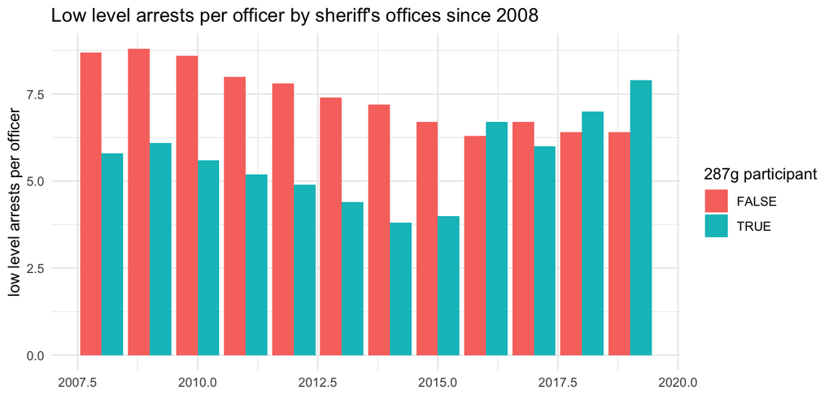

```r
# visualizing it
summary_agency_type_annual2 %>%
  filter(AGCYTYPE=="(001) Sheriff's office") %>%
  ggplot(aes(x=year, y=arrests_low_per_officer, group=participant, fill=participant)) +
  geom_bar(stat="identity", position="dodge") +
  theme_minimal() +
  labs(title="Low level arrests per officer by sheriff's offices since 2008",
       y="low level arrests per officer", x="", fill="287g participant")
```

Low-level arrest rates by year and participant groups.

```r
# low-level arrest rates
# bucketing up the years for sentence construction
summary_agency_type_annual2b <- joined2 %>%
  filter(year>=2008) %>%
  filter(!is.na(total_police_employees)) %>%
  filter(officers_total>3) %>%
  left_join(thou) %>%
  filter(is.na(outlier)) %>%
  mutate(grouped_year=case_when(
    year>=2008 & year < 2016 ~ "2008-2015",
    year>=2016 ~ "2016-2019",
    TRUE ~"other"
  )) %>%
  group_by(AGCYTYPE, participant, grouped_year) %>%
  summarize(total=n(),
            arrests_all=sum(arrests_all),
            arrests_low=sum(low_level_arrests),
            population=sum(population),
            population2=sum(LG_POPULATION),
            total_police = sum(total_police_employees),
            officers_total = sum(officers_total)) %>%
  mutate(
    arrests_per_police=round(arrests_all/total_police,1),
    arrests_per_officer=round(arrests_all/officers_total,1),
    arrests_low_per_police=round(arrests_low/total_police,1),
    arrests_low_per_officer=round(arrests_low/officers_total,1),
    percent_low=round(arrests_low/arrests_all*100,2)) %>%
  filter(AGCYTYPE=="(001) Sheriff's office") %>%
  select(AGCYTYPE, participant, grouped_year, arrests_low_per_officer) %>%
  pivot_wider(names_from="participant", values_from="arrests_low_per_officer") %>%
  rename(`Non-participant`=`FALSE`, Participant=`TRUE`)

datatable(summary_agency_type_annual2b %>% ungroup() %>%  select(-AGCYTYPE))
```

|  | grouped_year | Non-participant | Participant |
| --- | --- | --- | --- |
| 1 | 2008-2015 | 7.9 | 5 |
| 2 | 2016-2019 | 6.4 | 6.8 |

```r
# Calculating overall arrests per officer at agencies
# By year groups
summary_agency_type_annual2c <- joined2 %>%
  filter(year>=2008) %>%
  filter(!is.na(total_police_employees)) %>%
  filter(officers_total>3) %>%
  left_join(thou) %>%
  filter(is.na(outlier)) %>%
  mutate(grouped_year=case_when(
    year>=2008 & year < 2016 ~ "2008-2015",
    year>=2016 ~ "2016-2019",
    TRUE ~"other"
  )) %>%
  filter(!is.na(total_police_employees)) %>%
  group_by(AGCYTYPE, participant, grouped_year) %>%
  summarize(total=n(),
            arrests_all=sum(arrests_all),
            arrests_low=sum(low_level_arrests),
            population=sum(population),
            population2=sum(LG_POPULATION),
            total_police = sum(total_police_employees),
            officers_total = sum(officers_total)) %>%
  mutate(#arrests_per_pop=round(arrests/population*1000),
    #arrests_per_pop2=round(arrests/population2*1000000),
    arrests_per_police=round(arrests_all/total_police,1),
    arrests_per_officer=round(arrests_all/officers_total,1),
    arrests_low_per_police=round(arrests_low/total_police,1),
    arrests_low_per_officer=round(arrests_low/officers_total,1),
    percent_low=round(arrests_low/arrests_all*100,2)) %>%
  filter(AGCYTYPE=="(001) Sheriff's office") %>%
  select(AGCYTYPE, participant, grouped_year, arrests_per_officer) %>%
  pivot_wider(names_from="participant", values_from="arrests_low_per_officer") %>%
  rename(`Non-participant`=`FALSE`, Participant=`TRUE`)

datatable(summary_agency_type_annual2c %>% ungroup() %>% select(-AGCYTYPE))
```

```r
### agency

summary_agency_type_annual2ca <- joined2 %>%
  filter(year>=2008) %>%
  filter(!is.na(total_police_employees)) %>%
  filter(officers_total>3) %>%
  left_join(thou) %>%
  filter(is.na(outlier)) %>%
  mutate(grouped_year=case_when(
    year>=2008 & year < 2016 ~ "2008-2015",
    year>=2016 ~ "2016-2019",
    TRUE ~"other"
  )) %>%
  filter(!is.na(total_police_employees)) %>%
  group_by(AGCYTYPE, agency_name_edit, participant, grouped_year) %>%
  summarize(total=n(),
            arrests_all=sum(arrests_all),
            arrests_low=sum(low_level_arrests),
            population=sum(population),
            population2=sum(LG_POPULATION),
            total_police = sum(total_police_employees),
            officers_total = sum(officers_total)) %>%
  mutate(#arrests_per_pop=round(arrests/population*1000),
    #arrests_per_pop2=round(arrests/population2*1000000),
    arrests_per_police=round(arrests_all/total_police,1),
    arrests_per_officer=round(arrests_all/officers_total,1),
    arrests_low_per_police=round(arrests_low/total_police,1),
    arrests_low_per_officer=round(arrests_low/officers_total,1),
    percent_low=round(arrests_low/arrests_all*100,2)) %>%
  filter(AGCYTYPE=="(001) Sheriff's office") %>%
  select(AGCYTYPE, agency_name_edit, participant, grouped_year, arrests_per_officer) %>%
  pivot_wider(names_from="participant", values_from="arrests_per_officer") %>%
  rename(`Non-participant`=`FALSE`, Participant=`TRUE`) %>%
  select(-`Non-participant`) %>%
  filter(!is.na(Participant)) %>%
  pivot_wider(names_from=grouped_year, values_from=Participant) %>%
  filter(!is.na(`2008-2015`) & !is.na(`2016-2019`)) %>%
  mutate(change=round((`2016-2019`-`2008-2015`)/`2008-2015`*100,1))

datatable(summary_agency_type_annual2ca %>% ungroup() %>% select(-AGCYTYPE))
```

|  | agency_name_edit | 2008-2015 | 2016-2019 | change |
| --- | --- | --- | --- | --- |
| 1 | BENTON CO SO BENTONVILLE | 14.3 | 13.5 | -5.6 |
| 2 | CABARRUS CO SO CONCORD | 11.1 | 10.3 | -7.2 |
| 3 | CHARLESTON CO SO CHARLESTON | 9.6 | 7.3 | -24 |
| 4 | COBB CO SO MARIETTA | 2 | 1.7 | -15 |
| 5 | ETOWAH CO SO GADSDEN | 17.5 | 30.8 | 76 |
| 6 | FREDERICK CO SO FREDERICK | 20.5 | 21.6 | 5.4 |
| 7 | GASTON CO SO GASTONIA | 27.4 | 16.6 | -39.4 |
| 8 | GWINNETT COUNTY PD LAWRENCEVILLE | 8.1 | 16.2 | 100 |
| 9 | HALL CO SO GAINESVILLE | 8.1 | 9.1 | 12.3 |
| 10 | HARRIS CO SO HOUSTON | 16.1 | 14.9 | -7.5 |

[output cut: 13 more lines]

```r
# Calculating low-level arrests as a percent of all arrests

summary_agency_type_annual2d <- joined2 %>%
  filter(year>=2008) %>%
  filter(!is.na(total_police_employees)) %>%
  filter(officers_total>3) %>%
  left_join(thou) %>%
  filter(is.na(outlier)) %>%
  mutate(grouped_year=case_when(
    year>=2008 & year < 2016 ~ "2008-2015",
    year>=2016 ~ "2016-2019",
    TRUE ~"other"
  )) %>%
  filter(!is.na(total_police_employees)) %>%
  group_by(AGCYTYPE, participant, grouped_year) %>%
  summarize(total=n(),
            arrests_all=sum(arrests_all),
            arrests_low=sum(low_level_arrests),
            population=sum(population),
            population2=sum(LG_POPULATION),
            total_police = sum(total_police_employees),
            officers_total = sum(officers_total)) %>%
  mutate(
    arrests_per_police=round(arrests_all/total_police,1),
    arrests_per_officer=round(arrests_all/officers_total,1),
    arrests_low_per_police=round(arrests_low/total_police,1),
    arrests_low_per_officer=round(arrests_low/officers_total,1),
    percent_low=round(arrests_low/arrests_all*100,2)) %>%
  filter(AGCYTYPE=="(001) Sheriff's office") %>%
  select(AGCYTYPE, participant, grouped_year, percent_low) %>%
  pivot_wider(names_from="participant", values_from="percent_low") %>%
  rename(`Non-participant`=`FALSE`, Participant=`TRUE`)

datatable(summary_agency_type_annual2d %>% ungroup() %>% select(-AGCYTYPE))
```

Arrest rates per year by agency.

```r
#Comparing those two time periods, the low-level arrest rates
# for non-participating agencies dropped 17 percent while the
# rate for 287g participating agencies jumped 29 percent.

# identifying when agencies joined or left the program
# and seeing if arrest rates increased or not
summary_agency_type_annual6 <- joined2 %>%
  filter(year<=2018) %>%
  filter(!is.na(total_police_employees)) %>%
  filter(officers_total>3) %>%
  left_join(thou) %>%
  filter(is.na(outlier)) %>%
  group_by(AGCYTYPE, ori, participant, year) %>%
  summarize(total=n(),
            arrests_all=sum(arrests_all),
            arrests_low=sum(low_level_arrests),
            population=sum(population),
            population2=sum(LG_POPULATION),
            total_police = sum(total_police_employees),
            officers_total = sum(officers_total)) %>%
  mutate(
    arrests_per_police=round(arrests_all/total_police,1),
    arrests_per_officer=round(arrests_all/officers_total,1),
    arrests_low_per_police=round(arrests_low/total_police,1),
    arrests_low_per_officer=round(arrests_low/officers_total,1),
    percent_low=round(arrests_low/arrests_all*100,2)) %>%
  left_join(ice) %>%
  group_by(ori) %>%
  arrange(ori, year) %>%
  group_by(ori) %>%
  mutate(lag_arrests=lag(arrests_low_per_officer),
         lead_arrests=lead(arrests_low_per_officer),
         what_year_lag=case_when(
           what=="joined" | what=="left" ~ year-1),
         what_year_lead=case_when(
           what=="joined" | what=="left" ~ year+1)
  ) %>%
  filter(AGCYTYPE=="(001) Sheriff's office") %>%
  filter(ice==T) %>%
  #filter(!is.na(what)) %>%
  mutate(left_change=case_when(
    what=="left" & lag(year)==what_year_lag~ round((arrests_low_per_officer-lag_arrests)/lag_arrests*100,1),
    TRUE ~  NA_real_)
  ) %>%
  mutate(join_change=case_when(
    what=="joined" & lead(year)==what_year_lead~ round((lead_arrests-arrests_low_per_officer)/arrests_low_per_officer*100,1),
    TRUE ~  NA_real_)
  )  %>%
  filter(year>=2008)

summary_agency_type_annual6 %>%
  select(ori, participant, year, arrests_low, officers_total,
         arrests_low_per_officer, ice, left_change, join_change) %>%
  datatable()
```

|  | ori | participant | year | arrests_low | officers_total | arrests_low_per_officer | ice | left_change | join_change |
| --- | --- | --- | --- | --- | --- | --- | --- | --- | --- |
| 1 | AL0310000 | True | 2009 | 440 | 62 | 7.1 | True |  |  |
| 2 | AL0310000 | True | 2010 | 415 | 65 | 6.4 | True |  |  |
| 3 | AL0310000 | True | 2015 | 389 | 67 | 5.8 | True |  |  |
| 4 | AL0310000 | True | 2016 | 532 | 61 | 8.7 | True |  |  |
| 5 | AL0310000 | True | 2018 | 771 | 68 | 11.3 | True |  |  |
| 6 | AR0040000 | True | 2008 | 357 | 111 | 3.2 | True |  |  |
| 7 | AR0040000 | True | 2009 | 873 | 129 | 6.8 | True |  |  |
| 8 | AR0040000 | True | 2010 | 958 | 132 | 7.3 | True |  |  |
| 9 | AR0040000 | True | 2011 | 834 | 136 | 6.1 | True |  |  |
| 10 | AR0040000 | True | 2012 | 1128 | 138 | 8.2 | True |  |  |

[output cut: 787 more lines]

What’s the median rate decrease after agencies stop participating (through 2018 because only data through 2019 was available):

```r
# what's the median rate decrease after leaving
median(summary_agency_type_annual6$left_change, na.rm=T)
```

```
## [1] -3.05
```

```r
# -3
# 9 agencies dropped, 7 increased
```

What’s the median rate increase after participating (through 2018 because only data through 2019 was available):

```r
# what's the median rate increase after joining
round(median(summary_agency_type_annual6$join_change, na.rm=T),2)
```

```
## [1] 1.25
```

```r
# +1.25
```

Agencies analysis after 2016:

```r
# looking at agencies that ever participated
# and looking at their rate for low level arrests
# when they were participating versus when they weren't
summary_agency_type2 <- joined2 %>%
  #filter(year>=2008) %>%
  #filter(year<2016) %>%
  filter(year>=2016) %>%
  filter(year<=2019) %>%
  filter(!is.na(total_police_employees)) %>%
  filter(officers_total>3) %>%
  left_join(thou) %>%
  filter(is.na(outlier)) %>%
  filter(!is.na(ice)) %>%
  filter(AGCYTYPE=="(001) Sheriff's office") %>%
  group_by(state_abbr, agency_name_edit, ori, AGCYTYPE, participant) %>%
  summarize(total=n(),
            arrests_all=sum(arrests_all),
            arrests_low=sum(low_level_arrests),
            population=sum(population),
            population2=sum(LG_POPULATION),
            total_police = sum(total_police_employees),
            officers_total = sum(officers_total)) %>%
  mutate(#arrests_per_pop=round(arrests/population*1000),
    #arrests_per_pop2=round(arrests/population2*1000000),
    arrests_per_police=round(arrests_all/total_police,1),
    arrests_per_officer=round(arrests_all/officers_total,1),
    arrests_low_per_police=round(arrests_low/total_police,1),
    arrests_low_per_officer=round(arrests_low/officers_total,1),
    percent_low=round(arrests_low/arrests_all*100,2))

summary_agency_type2 %>%
  ungroup() %>%
  select(agency_name_edit, participant, arrests_low_per_officer) %>%
  datatable()
```

|  | agency_name_edit | participant | arrests_low_per_officer |
| --- | --- | --- | --- |
| 1 | ETOWAH CO SO GADSDEN | True | 10.1 |
| 2 | BENTON CO SO BENTONVILLE | True | 7.7 |
| 3 | WASHINGTON CO SO FAYETTEVILLE | True | 4.1 |
| 4 | MARICOPA CO SO PHOENIX | False | 5.8 |
| 5 | PIMA CO SHERIFF'S DEPARTMENT TUCSON | False | 6.7 |
| 6 | PINAL CO SO FLORENCE | True | 7.9 |
| 7 | YAVAPAI CO SO PRESCOTT | True | 10.2 |
| 8 | LOS ANGELES CO SO LOS ANGELES | False | 1.7 |
| 9 | ORANGE CO SO SANTA ANA | False | 0.8 |
| 10 | ORANGE CO SO SANTA ANA | True | 0.8 |

[output cut: 111 more lines]

```r
# adding a flag if the agency's low level arrest rate is higher
# than the average rate for these agencies
#arrests_low_per_officer_TRUE – rate of low level arrests while agency was participating in 287g
#arrests_low_per_officer_FALSE – rate of low level arrests while agency was not participating in 287g
#compare2 looks to see if their participation was higher than the average
#compare3 looks to see if their non participatoin rate was higher than the average
summary_agency_type3 <- summary_agency_type2 %>%
  select(state=state_abbr, agency=agency_name_edit, participant, total, arrests_low_per_officer) %>%
  pivot_wider(names_from="participant", values_from=c("total", "arrests_low_per_officer")) %>%
  mutate(compare=case_when(
    arrests_low_per_officer_TRUE > arrests_low_per_officer_FALSE ~ "more",
    TRUE ~ "less"),
    compare2=case_when(
      arrests_low_per_officer_TRUE > 7 ~ TRUE,
      TRUE ~ FALSE
    ),
    compare3=case_when(
      arrests_low_per_officer_FALSE > 7 ~ TRUE,
      TRUE ~ FALSE
    ))
```

```r
# replacing NAs in flag columns
# compare – flagging agencies that were always in 287g
# compare2 - flags whether arrests per officer is higher than the average of 7.1
# compare3 - flags whether arrests per officer is lower than the average of 7.1

summary_agency_type3$compare <- ifelse(is.na(summary_agency_type3$arrests_low_per_officer_FALSE), "no false", summary_agency_type3$compare )
summary_agency_type3$compare <- ifelse(is.na(summary_agency_type3$arrests_low_per_officer_TRUE), "no true", summary_agency_type3$compare )
summary_agency_type3$compare2 <- ifelse(is.na(summary_agency_type3$arrests_low_per_officer_TRUE), NA, summary_agency_type3$compare2)
summary_agency_type3$compare3 <- ifelse(is.na(summary_agency_type3$arrests_low_per_officer_FALSE), NA, summary_agency_type3$compare3)

# counting it up
# nothing really significant here
# 27 less, 28 more, no falses: 22
summary_agency_type3 %>% ungroup() %>%
  count(compare)

# 45 agencies who did not participate had higher rates than 32 that did participate
summary_agency_type3 %>% ungroup() %>%
  count(compare2)
```

```r
# in general, did these agencies exceed the average rate?
summary_agency_type5 <- joined2 %>%
  filter(year>=2008) %>%
  #filter(year<2016) %>%
  #filter(year>=2016) %>%

  filter(!is.na(total_police_employees)) %>%
  #filter(!is.na(ice)) %>%
  filter(officers_total>3) %>%
  left_join(thou) %>%
  filter(is.na(outlier)) %>%
  filter(AGCYTYPE=="(001) Sheriff's office") %>%
  group_by(state_abbr, agency_name_edit, ori, ice, AGCYTYPE) %>%
  summarize(total=n(),
            arrests_all=sum(arrests_all),
            arrests_low=sum(low_level_arrests),
            population=sum(population),
            population2=sum(LG_POPULATION),
            total_police = sum(total_police_employees),
            officers_total = sum(officers_total)) %>%
  mutate(
    arrests_per_police=round(arrests_all/total_police,1),
    arrests_per_officer=round(arrests_all/officers_total,1),
    arrests_low_per_police=round(arrests_low/total_police,1),
    arrests_low_per_officer=round(arrests_low/officers_total,1),
    percent_low=round(arrests_low/arrests_all*100,2)) %>%
  mutate(higher=case_when(
    arrests_low_per_officer > 7 ~ TRUE,
    TRUE ~ FALSE)) %>%
  ungroup() %>%
  mutate(rank=rank(-arrests_low_per_officer)) %>%
  arrange(rank) %>%
  mutate(percent_low=round(arrests_low/arrests_all*100,1)) %>%
  mutate(rank_percent=rank(-percent_low))

summary_agency_type7 <- full_join(summary_agency_type5, summary_agency_type3)

datatable(summary_agency_type7)
```